# PROJECT 3

# Part I - Exploration of ProsperLoan Dataset

## Introduction

> Here, the data set I will be exploring contains 113,937 loans with 81 variables on each loan. The dataset includes loan amount, borrower rate (or interest rate), current loan status, borrower income, and many others.

## Preliminary Wrangling

```python
# import all packages and set plots to be embedded inline
import numpy as np
import pandas as pd
import matplotlib.pyplot as plt
import seaborn as sb

%matplotlib inline
```

> Load prosperLoanData.csv in my dataset using pandas funtion pd.read_csv.

```python
# Loading prosperLoanData.cvs
loan_df = pd.read_csv('prosperLoanData.csv')
```

> in the next cell we will see the overview of data shape and composition

```python
# Checking shape of the dataset
loan_df.shape
```

```
(113937, 81)
```

```python
loan_df.dtypes
```

```
ListingKey                      object
ListingNumber                    int64
ListingCreationDate             object
CreditGrade                     object
Term                             int64
                                ...
PercentFunded                  float64
Recommendations                  int64
InvestmentFromFriendsCount       int64
InvestmentFromFriendsAmount    float64
Investors                        int64
Length: 81, dtype: object
```

```python
#checking the dataType

loan_df.dtypes
```

```
ListingKey                      object
ListingNumber                    int64
ListingCreationDate             object
CreditGrade                     object
Term                             int64
                                ...
PercentFunded                  float64
Recommendations                  int64
InvestmentFromFriendsCount       int64
InvestmentFromFriendsAmount    float64
Investors                        int64
Length: 81, dtype: object
```

```python
# Visual on the first five row of the dataset
loan_df.head()
```

|  | ListingKey | ListingNumber | ListingCreationDate | CreditGrade | Term | LoanStatus | ClosedDate | BorrowerAPR | BorrowerRate | LenderYield | ... | LP_ServiceFees | LP_CollectionFees | LP_GrossPrincipalLoss | LP_NetPrincipalLoss | LP_NonPrincipalRecoverypayments | PercentFunded | Recommendations | InvestmentFromFriendsCount | InvestmentFromFriendsAmount | Investors |
| --- | --- | --- | --- | --- | --- | --- | --- | --- | --- | --- | --- | --- | --- | --- | --- | --- | --- | --- | --- | --- | --- |
| 0 | 1021339766868145413AB3B | 193129 | 2007-08-26 19:09:29.263000000 | C | 36 | Completed | 2009-08-14 00:00:00 | 0.16516 | 0.1580 | 0.1380 | ... | -133.18 | 0.0 | 0.0 | 0.0 | 0.0 | 1.0 | 0 | 0 | 0.0 | 258 |
| 1 | 10273602499503308B223C1 | 1209647 | 2014-02-27 08:28:07.900000000 | NaN | 36 | Current | NaN | 0.12016 | 0.0920 | 0.0820 | ... | 0.00 | 0.0 | 0.0 | 0.0 | 0.0 | 1.0 | 0 | 0 | 0.0 | 1 |
| 2 | 0EE9337825851032864889A | 81716 | 2007-01-05 15:00:47.090000000 | HR | 36 | Completed | 2009-12-17 00:00:00 | 0.28269 | 0.2750 | 0.2400 | ... | -24.20 | 0.0 | 0.0 | 0.0 | 0.0 | 1.0 | 0 | 0 | 0.0 | 41 |
| 3 | 0EF5356002482715299901A | 658116 | 2012-10-22 11:02:35.010000000 | NaN | 36 | Current | NaN | 0.12528 | 0.0974 | 0.0874 | ... | -108.01 | 0.0 | 0.0 | 0.0 | 0.0 | 1.0 | 0 | 0 | 0.0 | 158 |
| 4 | 0F023589499656230C5E3E2 | 909464 | 2013-09-14 18:38:39.097000000 | NaN | 36 | Current | NaN | 0.24614 | 0.2085 | 0.1985 | ... | -60.27 | 0.0 | 0.0 | 0.0 | 0.0 | 1.0 | 0 | 0 | 0.0 | 20 |

5 rows × 81 columns

### What is the structure of this dataset?

```python
# A concise summary of the dataframe,including the number of non-null values in each colum
loan_df.info()
```

```
<class 'pandas.core.frame.DataFrame'>
RangeIndex: 113937 entries, 0 to 113936
Data columns (total 81 columns):
 #   Column                               Non-Null Count   Dtype
---  ------                               --------------   -----
 0   ListingKey                           113937 non-null  object
 1   ListingNumber                        113937 non-null  int64
 2   ListingCreationDate                  113937 non-null  object
 3   CreditGrade                          28953 non-null   object
 4   Term                                 113937 non-null  int64
 5   LoanStatus                           113937 non-null  object
 6   ClosedDate                           55089 non-null   object
 7   BorrowerAPR                          113912 non-null  float64
 8   BorrowerRate                         113937 non-null  float64
 9   LenderYield                          113937 non-null  float64
```

[output cut: 73 more lines]

> The dataset has 113,937 rows of data with 81 columns of variables. The structure includes;
> - ListingKey *ListingCreationDate*LoanOriginationDate *DateCreditPulled*ProsperRating *Term*ListingCategory *LoanOriginalAmount*BorrowerApr *EstimatedReturn*LoanStatus *StatedMonthlyIncome*IsBorrowerHomeowner And others.

### What is/are the main feature(s) of interest in your dataset?

> The borrower's interest rate (BorrowerRate) and the current loan status (LoanStatus) in this dataset will be the focus and main features of interest.

### What features in the dataset do you think will help support your investigation into your feature(s) of interest?

> In this dataset the features that will support the investigation of my features of interest include: the credit score of the applicant (CreditScoreRangeUpper), income range, employment status (EmploymentStatus), and debt to income ratio. Below are the possible questions we want to answer :
> - What are the factors that affects the borrower’s APR or interest rate?
> - what are the factors that influence loan’s outcome status?
> - Do loans differ depending on the size of the loan?

```python
#let's make a copy of our data so as not to tamper with the original dataset
new_loan_df = loan_df.copy()

#saving the copied data into the file prosperloan_edited.csv

new_loan_df.to_csv('prosperloan_edited.csv')
```

```python
#Loading the copied data
new_loan_df = pd.read_csv('prosperloan_edited.csv')
```

> Before we start our exploration, let's drop those data we will not need in this work

```python
new_loan_df.drop(columns=['ListingKey', 'ListingNumber', 'ListingCreationDate', 'CreditGrade', 'ClosedDate', 'LenderYield',\
                     'EstimatedEffectiveYield', 'EstimatedLoss', 'EstimatedReturn', 'ProsperRating (numeric)',\
                     'ProsperRating (Alpha)', 'BorrowerState', 'Occupation', 'EmploymentStatusDuration', 'CurrentlyInGroup',\
                     'GroupKey', 'DateCreditPulled', 'FirstRecordedCreditLine', 'CurrentCreditLines', 'OpenCreditLines',\
                     'TotalCreditLinespast7years', 'OpenRevolvingMonthlyPayment', 'InquiriesLast6Months', 'TotalInquiries',\
                     'DelinquenciesLast7Years', 'PublicRecordsLast10Years', 'PublicRecordsLast12Months', 'RevolvingCreditBalance',\
                     'BankcardUtilization', 'AvailableBankcardCredit', 'TotalTrades', 'TradesNeverDelinquent (percentage)', 'TradesOpenedLast6Months',\
                     'IncomeVerifiable', 'LoanKey', 'TotalProsperLoans', 'TotalProsperPaymentsBilled',\
                     'OnTimeProsperPayments', 'ProsperPaymentsLessThanOneMonthLate', 'ProsperPaymentsOneMonthPlusLate',\
                     'ProsperPrincipalBorrowed', 'ProsperPrincipalOutstanding', 'ScorexChangeAtTimeOfListing',\
                     'LoanFirstDefaultedCycleNumber', 'LoanMonthsSinceOrigination', 'LoanOriginationQuarter', 'MemberKey',\
                     'MonthlyLoanPayment', 'LP_CustomerPayments', 'LP_CustomerPrincipalPayments', 'LP_InterestandFees',\
                     'LP_ServiceFees', 'LP_CollectionFees', 'LP_GrossPrincipalLoss', 'LP_NetPrincipalLoss',\
                     'LP_NonPrincipalRecoverypayments', 'PercentFunded', 'Recommendations', 'InvestmentFromFriendsCount',\
                     'InvestmentFromFriendsAmount', 'Investors'], inplace=True)
```

> Now Loan Origination Date will be converted from string into datetime stamp

```python
# Convert LoanOriginationDate to a datetime dtype
new_loan_df.LoanOriginationDate = pd.to_datetime(new_loan_df.LoanOriginationDate)
```

```python
# Rename Columns that are not named in standard format
new_loan_df.rename(columns = {"ListingCategory (numeric)":"ListingCategory", "BorrowerAPR": "BorrowerApr"}, inplace = True)
```

```python
# Checking for summary description of Dataset
new_loan_df.describe()
```

|  | Unnamed: 0 | Term | BorrowerApr | BorrowerRate | ProsperScore | ListingCategory | CreditScoreRangeLower | CreditScoreRangeUpper | OpenRevolvingAccounts | CurrentDelinquencies | AmountDelinquent | DebtToIncomeRatio | StatedMonthlyIncome | LoanCurrentDaysDelinquent | LoanNumber | LoanOriginalAmount |
| --- | --- | --- | --- | --- | --- | --- | --- | --- | --- | --- | --- | --- | --- | --- | --- | --- |
| count | 113937.000000 | 113937.000000 | 113912.000000 | 113937.000000 | 84853.000000 | 113937.000000 | 113346.000000 | 113346.000000 | 113937.00000 | 113240.000000 | 106315.000000 | 105383.000000 | 1.139370e+05 | 113937.000000 | 113937.000000 | 113937.00000 |
| mean | 56968.000000 | 40.830248 | 0.218828 | 0.192764 | 5.950067 | 2.774209 | 685.567731 | 704.567731 | 6.96979 | 0.592052 | 984.507059 | 0.275947 | 5.608026e+03 | 152.816539 | 69444.474271 | 8337.01385 |
| std | 32890.923148 | 10.436212 | 0.080364 | 0.074818 | 2.376501 | 3.996797 | 66.458275 | 66.458275 | 4.63097 | 1.978707 | 7158.270157 | 0.551759 | 7.478497e+03 | 466.320254 | 38930.479610 | 6245.80058 |
| min | 0.000000 | 12.000000 | 0.006530 | 0.000000 | 1.000000 | 0.000000 | 0.000000 | 19.000000 | 0.00000 | 0.000000 | 0.000000 | 0.000000 | 0.000000e+00 | 0.000000 | 1.000000 | 1000.00000 |
| 25% | 28484.000000 | 36.000000 | 0.156290 | 0.134000 | 4.000000 | 1.000000 | 660.000000 | 679.000000 | 4.00000 | 0.000000 | 0.000000 | 0.140000 | 3.200333e+03 | 0.000000 | 37332.000000 | 4000.00000 |
| 50% | 56968.000000 | 36.000000 | 0.209760 | 0.184000 | 6.000000 | 1.000000 | 680.000000 | 699.000000 | 6.00000 | 0.000000 | 0.000000 | 0.220000 | 4.666667e+03 | 0.000000 | 68599.000000 | 6500.00000 |
| 75% | 85452.000000 | 36.000000 | 0.283810 | 0.250000 | 8.000000 | 3.000000 | 720.000000 | 739.000000 | 9.00000 | 0.000000 | 0.000000 | 0.320000 | 6.825000e+03 | 0.000000 | 101901.000000 | 12000.00000 |
| max | 113936.000000 | 60.000000 | 0.512290 | 0.497500 | 11.000000 | 20.000000 | 880.000000 | 899.000000 | 51.00000 | 83.000000 | 463881.000000 | 10.010000 | 1.750003e+06 | 2704.000000 | 136486.000000 | 35000.00000 |

```python
#let's look at the information on our rearranged dataset
new_loan_df.info()
```

```
<class 'pandas.core.frame.DataFrame'>
RangeIndex: 113937 entries, 0 to 113936
Data columns (total 21 columns):
 #   Column                     Non-Null Count   Dtype
---  ------                     --------------   -----
 0   Unnamed: 0                 113937 non-null  int64
 1   Term                       113937 non-null  int64
 2   LoanStatus                 113937 non-null  object
 3   BorrowerApr                113912 non-null  float64
 4   BorrowerRate               113937 non-null  float64
 5   ProsperScore               84853 non-null   float64
 6   ListingCategory            113937 non-null  int64
 7   EmploymentStatus           111682 non-null  object
 8   IsBorrowerHomeowner        113937 non-null  bool
 9   CreditScoreRangeLower      113346 non-null  float64
 10  CreditScoreRangeUpper      113346 non-null  float64
 11  OpenRevolvingAccounts      113937 non-null  int64
 12  CurrentDelinquencies       113240 non-null  float64
 13  AmountDelinquent           106315 non-null  float64
 14  DebtToIncomeRatio          105383 non-null  float64
 15  IncomeRange                113937 non-null  object
 16  StatedMonthlyIncome        113937 non-null  float64
 17  LoanCurrentDaysDelinquent  113937 non-null  int64
 18  LoanNumber                 113937 non-null  int64
 19  LoanOriginalAmount         113937 non-null  int64
 20  LoanOriginationDate        113937 non-null  datetime64[ns]
dtypes: bool(1), datetime64[ns](1), float64(9), int64(7), object(3)
memory usage: 17.5+ MB
```

## Univariate Exploration

> let's start by looking at the distribution of the main variables of interest:

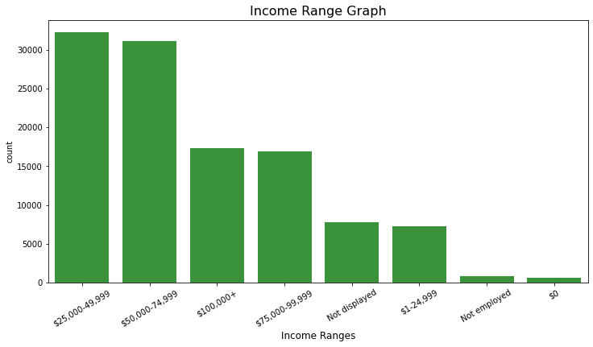

```python
# standard-scaled bar plot for Income Range

income_class = new_loan_df['IncomeRange'].value_counts().index
plt.figure(figsize=[12, 6])
default_color = sb.color_palette()[2]
sb.countplot(data=new_loan_df, x='IncomeRange', color=default_color, order=income_class)
plt.title('Income Range Graph', fontsize=16)
plt.xlabel('Income Ranges', fontsize=12)
plt.xticks(rotation=30);
```

```python
# income range order (list)

income_range_order = ['Not employed', '$0', '$1-24,999','$25,000-49,999','$50,000-74,999', '$75,000-99,999','$100,000+', 'Not displayed']
```

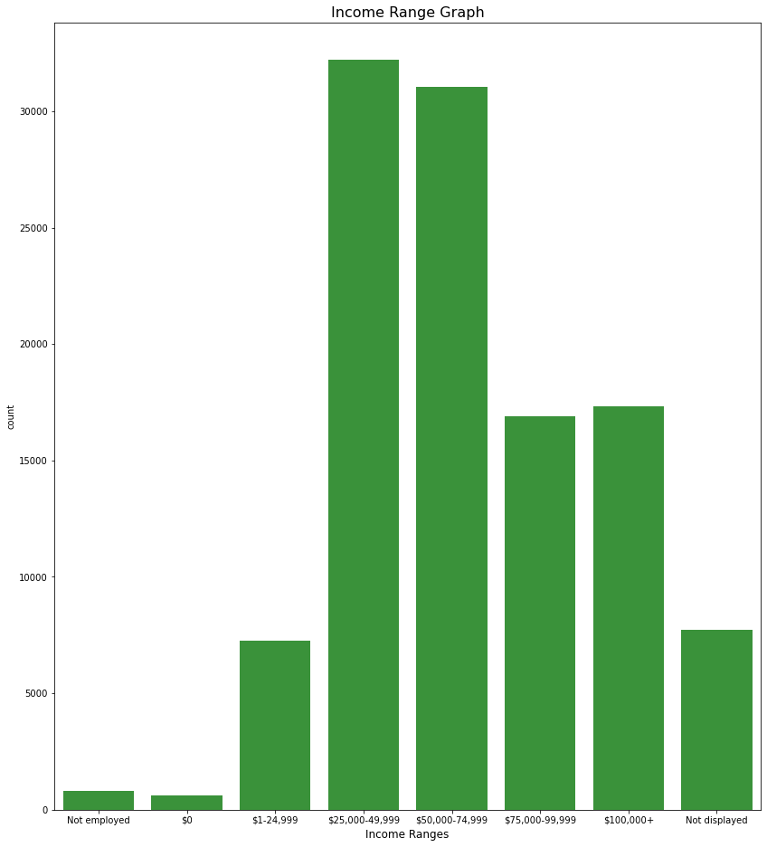

```python
# standard-scaled bar plot for Income Range

plt.figure(figsize=[14, 16])
default_color = sb.color_palette()[2]
sb.countplot(data=new_loan_df, x='IncomeRange', color=default_color, order=income_range_order)
plt.title('Income Range Graph', fontsize=16)
plt.xlabel('Income Ranges', fontsize=12)
```

> From the diagram anove, we can see that much of the income in this dataset is concerntrated around 25000 USD and 4999 USD

> Next, let's look at the distribution of the Borrower's Interest rate ((BorrowerRate):

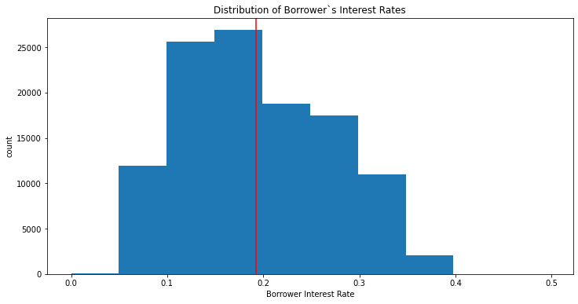

```python
#Ploting hist graph for BorrowerRate

mean_rate = new_loan_df.BorrowerRate.mean()

#Plotting
plt.figure(figsize=[12, 6])
plt.hist(data = new_loan_df, x = 'BorrowerRate')
plt.xlabel('Borrower Interest Rate');
plt.ylabel('count')
plt.axvline(x=mean_rate, color='r');
plt.title('Distribution of Borrower`s Interest Rates');
```

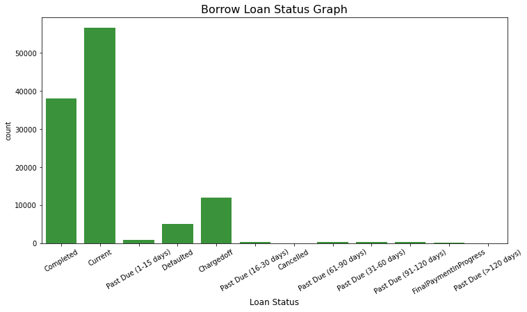

```python
# bar graph for Loan Status

plt.figure(figsize=[12, 6])
sb.countplot(data=new_loan_df, x='LoanStatus', color=default_color);
plt.xticks(rotation=90);
plt.title('Borrow Loan Status Graph', fontsize=16)
plt.xlabel('Loan Status', fontsize=12)
plt.xticks(rotation=30);
```

```python
# all past Due loans will be combined into a unique loan status called 'Past_due'

new_loan_df['LoanStatus'] = new_loan_df['LoanStatus'].apply(lambda x: x if 'Past Due' not in x else 'Past Due')

# Convert LoanStatus to a categorical variable
status_dict = ['Defaulted','Chargedoff', 'Past_due', 'FinalPaymentInProgress','Current', 'Completed']

ranked_loan_status = pd.api.types.CategoricalDtype(ordered = True, categories = status_dict)

new_loan_df['LoanStatus'] = new_loan_df['LoanStatus'].astype(ranked_loan_status)
```

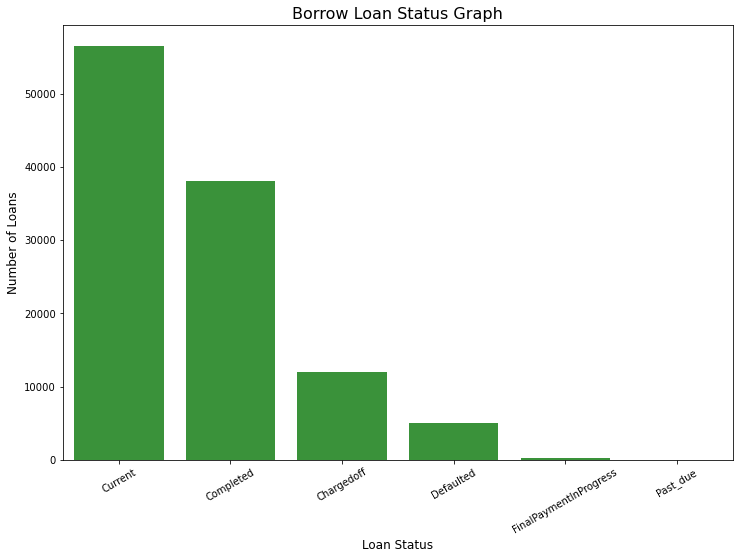

```python
# Re-Plotting LoanStatus bar chat

df_color = sb.color_palette()[2]

# Putting the categorical variable type orderly

ordered_category = new_loan_df['LoanStatus'].value_counts().index
plt.figure(figsize=(12,8))
sb.countplot(data = new_loan_df, x = 'LoanStatus', color = df_color, order= ordered_category)
plt.ylabel('Number of Loans', fontsize=12)
plt.title('Borrow Loan Status Graph', fontsize=16)
plt.xticks(rotation=30)
plt.xlabel('Loan Status', fontsize=12)
```

> From the graph above, we can see that most of the loans are either in current or completed status.

```python
# the code here will show the percentages of loans in each status

status_percent = pd.DataFrame(new_loan_df.groupby('LoanStatus')['LoanStatus'].count())
status_percent['Loan Status (%)'] = (status_percent['LoanStatus']/status_percent['LoanStatus'].sum())*100
status_percent.sort_values(by='Loan Status (%)', ascending=False)
```

| LoanStatus | LoanStatus | Loan Status (%) |
| --- | --- | --- |
| Current | 56576 | 50.575247 |
| Completed | 38074 | 34.035668 |
| Chargedoff | 11992 | 10.720064 |
| Defaulted | 5018 | 4.485764 |
| FinalPaymentInProgress | 205 | 0.183257 |
| Past_due | 0 | 0.000000 |

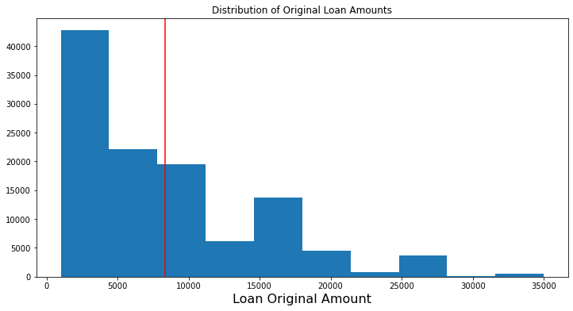

```python
# Visualization for Loan Original Amount

avg_loan_amount = new_loan_df.LoanOriginalAmount.mean()

plt.figure(figsize=[12, 6])
plt.hist(data = new_loan_df, x = 'LoanOriginalAmount')
plt.xlabel('Loan Original Amount', fontsize=16);
plt.axvline(x=avg_loan_amount, color='r');
plt.title('Distribution of Original Loan Amounts', fontsize=12);
```

[figure not shown]

```python
# because of the long tail in the distribution, we will put loan amount on a log scale instead
log_binsize = 0.05
bins = 10 ** np.arange(2.4, np.log10(new_loan_df['LoanOriginalAmount'].max())+log_binsize, log_binsize)

plt.figure(figsize=[8, 5])
plt.hist(data = new_loan_df, x = 'LoanOriginalAmount', bins = bins)
plt.xscale('log')
plt.xticks([500, 1e3, 2e3, 5e3, 1e4, 2e4], [4000, '10k', '20k', '25k', '30k', '35k'])
plt.xlabel('Loan Original Amount', fontsize=16);
plt.ylabel('counts', fontsize=12)
plt.axvline(x=avg_loan_amount, color='r');
plt.title('Distribution of Original Loan Amounts: log scale', fontsize=12);
```

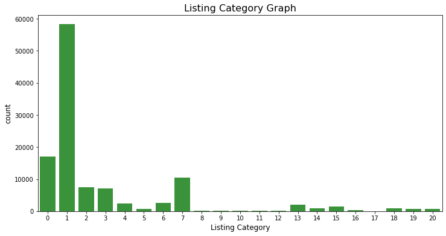

```python
# Plotting ListingCategory bar standard plot to investigate why

plt.figure(figsize=[12, 6])
sb.countplot(data=new_loan_df, x='ListingCategory', color=default_color);
plt.title('Listing Category Graph', fontsize=16)
plt.xlabel('Listing Category', fontsize=12)
plt.ylabel('count', fontsize=12);
```

> Perhaps a lot of the loans were debt consolidation. This happens when several loans or liabilities are combined into one by taking out a new loan to pay off the debts.

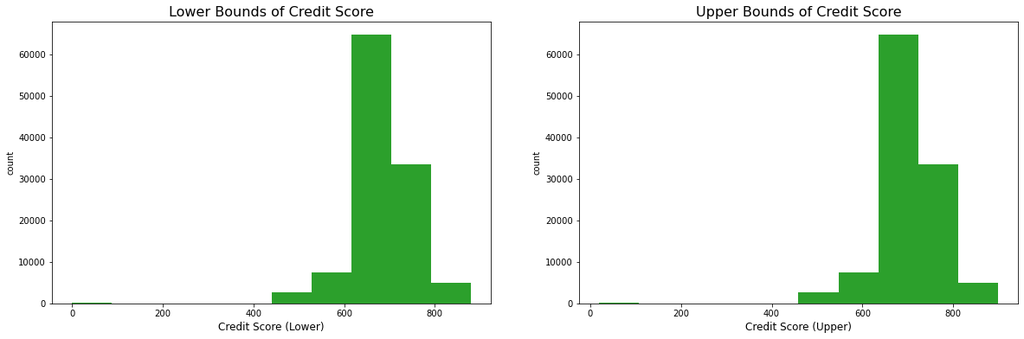

```python
# lets show the graphs of Credit Score Range Lower and Credit Score Range Upper side by side.

plt.figure(figsize=[20,6])

#Plotting graph to the left
plt.subplot(1,2,1)
plt.hist(data = new_loan_df, x = 'CreditScoreRangeLower', color = default_color);
plt.title('Lower Bounds of Credit Score', fontsize=16)
plt.xlabel('Credit Score (Lower)', fontsize=12)
plt.ylabel('count');

#Plotting graph at right side
plt.subplot(1,2,2)
plt.hist(data = new_loan_df, x = 'CreditScoreRangeUpper', color = default_color);
plt.title('Upper Bounds of Credit Score', fontsize=16)
plt.xlabel('Credit Score (Upper)', fontsize=12)
plt.ylabel('count');
```

> From the visualizations above, both distributions are exactly the same.

### Discuss the distribution(s) of your variable(s) of interest. Were there any unusual points? Did you need to perform any transformations?

> From the exploratory analysis we observe that most of Prosper's borrowers are have Jobs, and that most of loans are in current status.

## Bivariate Exploration

> In this section, I will show the relationships between pairs of variables in my data. Note that the variables covered here have been introduced in the previous sections (univariate exploration).

```python
# The Numberical and Categorical features in my dataset are;

numerical_vars = ['BorrowerRate', 'CreditScoreRangeUpper', 'OpenRevolvingAccounts', 'AmountDelinquent', 'DebtToIncomeRatio',
                  'StatedMonthlyIncome', 'LoanOriginalAmount']
categorical_vars = ['LoanStatus', 'EmploymentStatus', 'ListingCategory', 'IncomeRange']
```

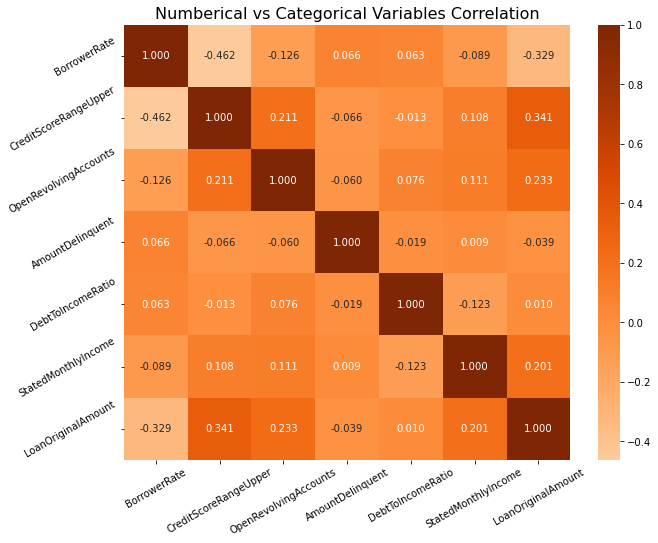

```python
# Heat Map Correlation plot

df_color = sb.color_palette()[3]
plt.figure(figsize = [10, 8])
sb.heatmap(new_loan_df[numerical_vars].corr(), annot = True, fmt = '.3f', cmap = 'Oranges', center = 0)
plt.title('Numberical vs Categorical Variables Correlation', fontsize=16)
plt.xticks(rotation=30)
plt.yticks(rotation=30)
plt.show();
```

> Heat Map plot shows that there is correlation between Credit score and Borrow Rate

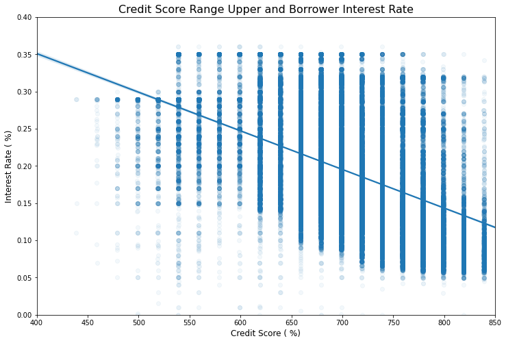

```python
# Credit Score range upper and borrower rate correlation visualization

plt.figure(figsize=(12,8))
sb.regplot(data=new_loan_df, x='CreditScoreRangeUpper', y="BorrowerRate", truncate=False, x_jitter=0.3, scatter_kws={'alpha':1/20});
plt.xlim(400, 850);
plt.ylim(0, .4);
plt.xlabel('Credit Score ( %)', fontsize=12);
plt.ylabel('Interest Rate ( %)', fontsize=12 );
plt.title('Credit Score Range Upper and Borrower Interest Rate', fontsize=16);
plt.show()
```

> From the above graph, we can see that there is a weak negative correlation between the credit score and the borrower interest rate. when the credit score increases, the interest rate decreases (but at a slow rate).

[figure not shown]

```python
plt.figure(figsize = [15, 20])

# subplot 1: EmploymentStatus and LoanStatus
ax= plt.subplot(3, 1, 1)
sb.countplot(data = new_loan_df, x = 'LoanStatus', hue ='EmploymentStatus' , palette = 'bright')
ax.legend(loc=2, ncol = 4, title='Loan Status');
plt.title(' Loan Status and Employment Status', fontsize = 16)
plt.xlabel('Employment Status', fontsize=12)
plt.ylabel('count', fontsize=12)
plt.xticks(rotation=30);
```

[figure not shown]

```python
#Plot the categorical variables against each other
plt.figure(figsize = [15, 20])

# subplot 1: EmploymentStatus and LoanStatus
ax= plt.subplot(3, 1, 1)
sb.countplot(data = new_loan_df, x = 'LoanStatus', hue ='EmploymentStatus' , palette = 'bright')
ax.legend(loc=2, ncol = 4, title='Loan Status');
plt.title(' Loan Status and Employment Status', fontsize = 16)
plt.xlabel('Employment Status', fontsize=12)
plt.ylabel('count', fontsize=12)
plt.xticks(rotation=6); #the xticks have been rearranged to avoid over lapping



# subplot 2: EmploymentStatus and ListingCategory
ax = plt.subplot(3, 1, 2)
sb.countplot(data = new_loan_df, x = 'EmploymentStatus', hue = 'ListingCategory', palette = 'bright')
ax.legend(loc=2, ncol = 5, title="Listing Category");
plt.title('Graph of Employment vs Listing Category', fontsize = 16)
plt.xlabel('Employment Status', fontsize=12)
plt.ylabel('count', fontsize=12)
plt.xticks(rotation=8);



# subplot 3: LoanStatus and ListingCategory
ax = plt.subplot(3, 1, 3)
sb.countplot(data = new_loan_df, x = 'LoanStatus', hue = 'ListingCategory', palette = 'bright')
ax.legend(loc = 1, ncol = 4, title="Listing Category");
plt.title('Visualization on Loan status and Listing Category', fontsize = 16)
plt.xlabel('Loan Status', fontsize=12)
plt.ylabel('count', fontsize=12)
plt.xticks(rotation=30);
```

> Let's take a closer look at Borrowers Rate and Original Loan Amounts as Compared to Loan Status in the next cell:

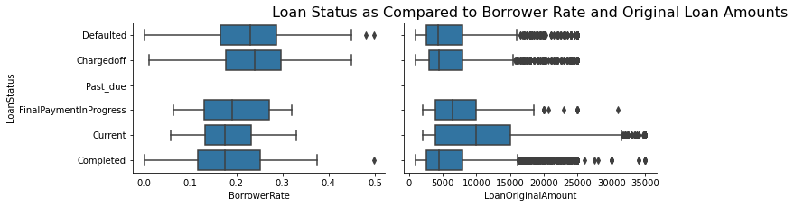

```python
def boxgrid(x, y, **kwargs):
    base_color= sb.color_palette()[0]
    sb.boxplot(x=x, y=y, color = base_color)

# Ploating
plt.figure(figsize = [20, 40]);
g = sb.PairGrid(data = new_loan_df, y_vars = 'LoanStatus' , x_vars = ['BorrowerRate', 'LoanOriginalAmount'], height = 3, aspect = 1.5);
g.map(boxgrid);
plt.title('Loan Status as Compared to Borrower Rate and Original Loan Amounts', fontsize=16);
```

> We can see that there is little difference between the categories of LoanStatus and the borrower interest rate. Do note that, charged off and defaulted loans are higher than the rest of the loans. If we compare loan status to the original loan amounts, we can see that larger loan create mores chance of staying in current loan status.

### Talk about some of the relationships you observed in this part of the investigation. How did the feature(s) of interest vary with other features in the dataset?

> We can observe that the average loan amount for the defaulted or overdue dataframe was less than the dataframe as a whole but the interest rate for those loans was higher by .04.

> The heat map also showed that the positive correlations among the numeric variables are not so strong. However, only a negative relationship between borrower interest rates and credit score were stronger,

## Multivariate Exploration

> In this section, I will create plots for three variables and investidate further in detail the impact of credit score and loan amount on borrower interest rates.

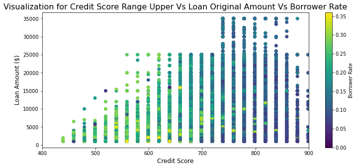

```python
# showing Scatter plot using original LoanOriginalAmount

plt.figure(figsize=[12,5])
plt.scatter(data=new_loan_df, x='CreditScoreRangeUpper', y='LoanOriginalAmount', c='BorrowerRate');
plt.colorbar(label='Borrower Rate');
plt.xlim(400, 900);
plt.title('Visualization for Credit Score Range Upper Vs Loan Original Amount Vs Borrower Rate', fontsize=16)
plt.ylabel('Loan Amount ($)', fontsize=12);
plt.xlabel('Credit Score', fontsize=12);
```

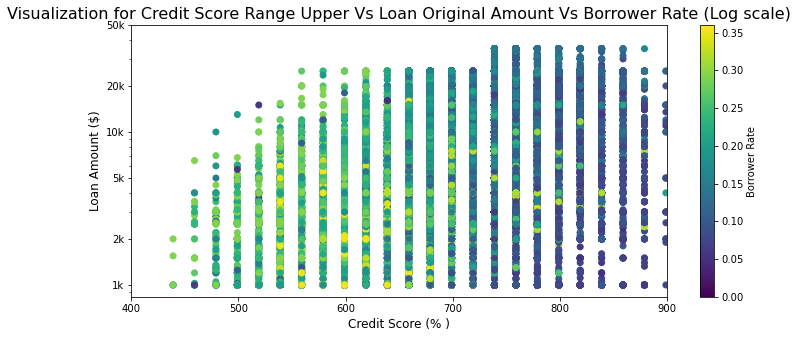

```python
#showing Scatter plot using original log LoanOriginalAmount

plt.figure(figsize=[12,5])
plt.scatter(data=new_loan_df, x='CreditScoreRangeUpper', y='LoanOriginalAmount', c='BorrowerRate');
plt.colorbar(label='Borrower Rate');
plt.yscale('log')
plt.yticks([1e3, 2e3, 5e3, 1e4, 2e4, 5e4], ['1k', '2k', '5k','10k', '20k', '50k'])
plt.xlim(400, 900);
plt.title('Visualization for Credit Score Range Upper Vs Loan Original Amount Vs Borrower Rate (Log scale)', fontsize=16)
plt.ylabel('Loan Amount ($)', fontsize=12);
plt.xlabel('Credit Score (% )', fontsize=12);
```

> The visualization above showed that the borrower's credit score and borrowers interest rate have negative relationship. Although it is not as serous as we can imagine, there are some instances whereloan amount affect on the interest rate as well.

> The scatter plots below will show the relationships between borrower interest rates, credit scores, and income:

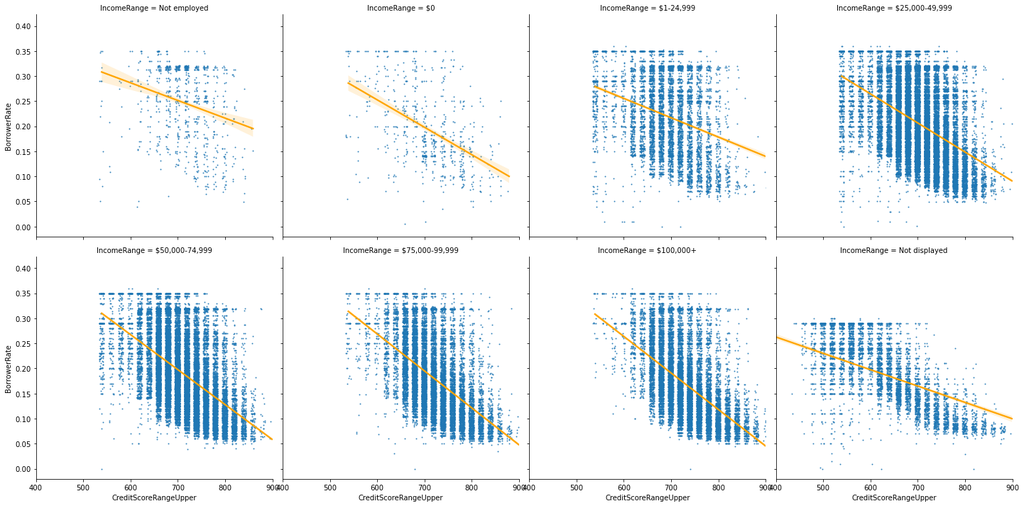

```python
#scatterplot to show the relationship between BorrowerRate, CreditScoreRangeUpper, and IncomeRange

gird = sb.FacetGrid(data = new_loan_df, col='IncomeRange', height=5, col_wrap=4, col_order = income_range_order)
gird.map(sb.regplot, 'CreditScoreRangeUpper', 'BorrowerRate', x_jitter = 5, scatter_kws= {'s':1}, line_kws={'color':'orange'});
plt.xlim(400, 900);

## the code below will set plot dimension figure level
g.fig.set_size_inches(16,8);
```

```python
#Plot relationship of LoanStatus against LoanAmount and BorrowerRate

fig, ax = plt.subplots(ncols=2, figsize = [20,5])
sb.pointplot(data = new_loan_df, x = 'LoanStatus', y = 'LoanOriginalAmount', hue = 'EmploymentStatus',
           palette = 'Greens', linestyles = '', dodge = 0.4, ax=ax[0])
ax[0].set_title('comparing Loan Outcome to Loan Amounts and Employment Status')
ax[0].set_ylabel('Loan Amount ($)')
ax[0].set_xlabel('Loan Outcome ($)')
ax[0].legend(loc=2, ncol=4, framealpha=1);
ax[0].tick_params('x', labelrotation=30);

sb.pointplot(data = new_loan_df, x = 'LoanStatus', y = 'BorrowerRate', hue = 'EmploymentStatus',
           palette = 'Blues', linestyles = '', dodge = 0.4, ax=ax[1])
ax[1].set_title('comparing Loan Outcome to Borrower Interest Rates and Employment Status')
ax[1].set_ylabel('Borrower Interest Rate')
ax[1].set_xlabel('Loan Outcome ($)')
ax[1].legend(loc=2, ncol=4, framealpha=1);
ax[1].tick_params('x', labelrotation=30);
```

[output not shown]

### Did you observe any interesting relationships between the other features (not the main feature(s) of interest)?

> I thought unemployed people will default on thier loans but the reverse was the case here. The people who are defaulting on thier loans are the fully employed people.

## Conclusions

In this project we tried to answer the following questions:

> - What factors affect a loan’s outcome status?
> - What factors affects the borrower’s APR or interest rate?
> - Are there differences between loans depending on how large the original loan amount was?

> looking at the correlation between loan status and the original loan amounts, we can say to some extent that the larger the loan amount, the more chance of being in current loan status. Thus differences between loans have positive relationship on the original loan amount.

> The biggest challenge with this project was figuring out what features to choose from the wide array of variables. towardsdatascience.com, kaggle and github were referenced for some guidance.